# Practical Machine Learning Project

Bri

11/13/2020

## Introduction

In this project the objective is to use machine learning to predict the manner in which individuals perform certain exercises. The data was created from wearable accelerometers.

We will first read in the training data and do some data cleanup:

```r
library(caret)
library(gbm)
library(randomForest)
# read in downloaded training data
dat = read.csv("C:/Users/sunid/Downloads/pml-training.csv", row.names = 1)

# take a look at the data
# change class of dat$classe to factor
# change NA to zero

head(dat)
```

```
##   user_name raw_timestamp_part_1 raw_timestamp_part_2   cvtd_timestamp
## 1  carlitos           1323084231               788290 05/12/2011 11:23
## 2  carlitos           1323084231               808298 05/12/2011 11:23
## 3  carlitos           1323084231               820366 05/12/2011 11:23
## 4  carlitos           1323084232               120339 05/12/2011 11:23
## 5  carlitos           1323084232               196328 05/12/2011 11:23
## 6  carlitos           1323084232               304277 05/12/2011 11:23
##   new_window num_window roll_belt pitch_belt yaw_belt total_accel_belt
## 1         no         11      1.41       8.07    -94.4                3
## 2         no         11      1.41       8.07    -94.4                3
## 3         no         11      1.42       8.07    -94.4                3
## 4         no         12      1.48       8.05    -94.4                3
## 5         no         12      1.48       8.07    -94.4                3
## 6         no         12      1.45       8.06    -94.4                3
##   kurtosis_roll_belt kurtosis_picth_belt kurtosis_yaw_belt skewness_roll_belt
```

[output cut: 251 more lines]

```r
dim(dat)
```

```
## [1] 19622   159
```

```r
class(dat$classe)
```

```
## [1] "character"
```

```r
dat$classe <- as.factor(dat$classe)
dat[is.na(dat)] <- 0
```

## Identifying features

```r
# set.seed
set.seed(190)

# create training and testing sets: 60:40 split

inTrain <- createDataPartition(dat$classe, p = 0.6, list = FALSE)

training <- dat[inTrain,]
testing <- dat[-inTrain,]

# identify highly correlating features to remove
# calculate correlation matrix
correlationMatrix <- cor(data.matrix(training[,-159]))



# identify features that are highly corrected
highCorr <- findCorrelation(correlationMatrix, cutoff=0.8, names = TRUE)

# print indexes of highly correlated attributes
highCorr
```

```
##  [1] "cvtd_timestamp"           "kurtosis_yaw_belt"
##  [3] "skewness_roll_belt.1"     "skewness_yaw_belt"
##  [5] "min_roll_belt"            "amplitude_yaw_belt"
##  [7] "stddev_roll_belt"         "stddev_pitch_belt"
##  [9] "avg_yaw_belt"             "accel_belt_x"
## [11] "accel_belt_z"             "gyros_arm_y"
## [13] "skewness_roll_arm"        "max_yaw_arm"
## [15] "amplitude_roll_arm"       "amplitude_pitch_arm"
## [17] "amplitude_yaw_arm"        "kurtosis_yaw_dumbbell"
## [19] "skewness_yaw_dumbbell"    "amplitude_pitch_dumbbell"
## [21] "amplitude_yaw_dumbbell"   "stddev_pitch_dumbbell"
## [23] "stddev_yaw_dumbbell"      "accel_dumbbell_x"
## [25] "accel_dumbbell_z"         "kurtosis_roll_forearm"
## [27] "kurtosis_yaw_forearm"     "skewness_pitch_forearm"
## [29] "skewness_yaw_forearm"     "max_yaw_forearm"
```

[output cut: 20 more lines]

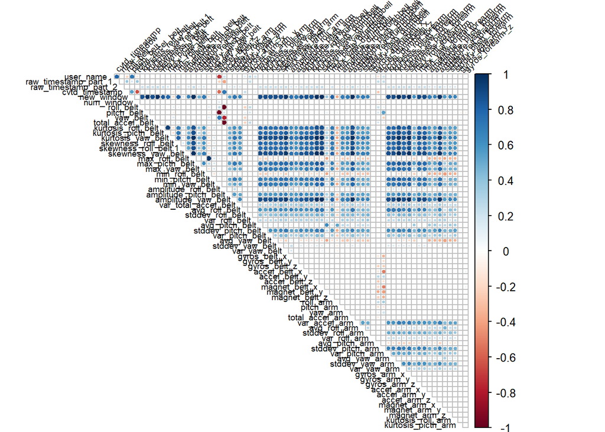

```r
# plotting highly correlating features
library(corrplot)
corrplot(correlationMatrix[, colnames(correlationMatrix) %in% highCorr], type = "upper", tl.col = "black", tl.srt = 45, tl.cex = 0.6)
```

```r
# make data frame with uncorrelated features
trainMod <- data.frame(classe = as.factor(training$classe), training[, colnames(training) %in% highCorr])

# check dimensions and column names of new training set
dim(trainMod)
```

```
## [1] 11776    70
```

```r
colnames(trainMod)
```

```
##  [1] "classe"                   "cvtd_timestamp"
##  [3] "new_window"               "roll_belt"
##  [5] "pitch_belt"               "total_accel_belt"
##  [7] "kurtosis_roll_belt"       "kurtosis_yaw_belt"
##  [9] "skewness_roll_belt.1"     "skewness_yaw_belt"
## [11] "max_picth_belt"           "max_yaw_belt"
## [13] "min_roll_belt"            "min_pitch_belt"
## [15] "amplitude_roll_belt"      "amplitude_pitch_belt"
## [17] "amplitude_yaw_belt"       "stddev_roll_belt"
## [19] "stddev_pitch_belt"        "avg_yaw_belt"
## [21] "stddev_yaw_belt"          "accel_belt_x"
## [23] "accel_belt_z"             "stddev_roll_arm"
## [25] "stddev_pitch_arm"         "stddev_yaw_arm"
## [27] "gyros_arm_y"              "accel_arm_x"
## [29] "magnet_arm_y"             "kurtosis_roll_arm"
```

[output cut: 20 more lines]

```r
# remove "cvtd_timestamp" and "new_window" features
trainMod <- (subset(trainMod, select = -c(cvtd_timestamp,new_window)))


# check data frame
head(trainMod)
```

```
##    classe roll_belt pitch_belt total_accel_belt kurtosis_roll_belt
## 1       A      1.41       8.07                3
## 2       A      1.41       8.07                3
## 5       A      1.48       8.07                3
## 8       A      1.42       8.13                3
## 9       A      1.43       8.16                3
## 11      A      1.45       8.18                3
##    kurtosis_yaw_belt skewness_roll_belt.1 skewness_yaw_belt max_picth_belt
## 1                                                                        0
## 2                                                                        0
## 5                                                                        0
## 8                                                                        0
## 9                                                                        0
## 11                                                                       0
##    max_yaw_belt min_roll_belt min_pitch_belt amplitude_roll_belt
```

[output cut: 111 more lines]

```r
# remove features with near zero variance
nzv <- nearZeroVar(trainMod)
filtered_trainMod <- trainMod[, -nzv]
```

## Identifying the best machine learning algorithm

After this, we will train models using various different machine learning algorithms available in the caret package. We will choose the best algorithm based on accuracy. For all methods, we use 5-fold cross validation.

```r
# train random forest
# using 5-fold cross validation throughout
fitControl <- trainControl(method = "cv",
                           number = 5,
                           allowParallel = FALSE,
                           savePredictions = TRUE,
                           classProbs = TRUE)

fit_rf <- train(classe ~. , data = filtered_trainMod, method = "rf", trControl = fitControl, preProcess = c("center", "scale"))

fit_rf
```

```
## Random Forest
##
## 11776 samples
##    13 predictor
##     5 classes: 'A', 'B', 'C', 'D', 'E'
##
## Pre-processing: centered (13), scaled (13)
## Resampling: Cross-Validated (5 fold)
## Summary of sample sizes: 9421, 9420, 9421, 9421, 9421
## Resampling results across tuning parameters:
##
##   mtry  Accuracy  Kappa
##    2    0.957965  0.9468474
##    7    0.950832  0.9378259
##   13    0.935122  0.9179754
##
## Accuracy was used to select the optimal model using the largest value.
## The final value used for the model was mtry = 2.
```

```r
# train gbm
fitControl <- trainControl(method = "cv",
                           number = 5,
                           allowParallel = FALSE,
                           savePredictions = TRUE,
                           classProbs = TRUE)

fit_gbm <- train(classe ~. , data = filtered_trainMod, method = "gbm", trControl = fitControl, preProcess = c("center", "scale"))
fit_gbm
```

```
## Stochastic Gradient Boosting
##
## 11776 samples
##    13 predictor
##     5 classes: 'A', 'B', 'C', 'D', 'E'
##
## Pre-processing: centered (13), scaled (13)
## Resampling: Cross-Validated (5 fold)
## Summary of sample sizes: 9420, 9422, 9420, 9421, 9421
## Resampling results across tuning parameters:
##
##   interaction.depth  n.trees  Accuracy   Kappa
##   1                   50      0.5900136  0.4749224
##   1                  100      0.6571854  0.5632848
##   1                  150      0.6909825  0.6069806
##   2                   50      0.7238464  0.6490191
##   2                  100      0.7854958  0.7277182
##   2                  150      0.8183610  0.7695810
##   3                   50      0.7838826  0.7257003
##   3                  100      0.8389110  0.7958075
##   3                  150      0.8648968  0.8289159
##
## Tuning parameter 'shrinkage' was held constant at a value of 0.1
##
## Tuning parameter 'n.minobsinnode' was held constant at a value of 10
## Accuracy was used to select the optimal model using the largest value.
## The final values used for the model were n.trees = 150, interaction.depth =
##  3, shrinkage = 0.1 and n.minobsinnode = 10.
```

```r
# train rpart
fitControl <- trainControl(method = "cv",
                           number = 5,
                           allowParallel = FALSE,
                           savePredictions = TRUE,
                           classProbs = TRUE)

fit_rpart <- train(classe ~. , data = filtered_trainMod, method = "rpart", trControl = fitControl, preProcess = c("center", "scale"))

fit_rpart
```

```
## CART
##
## 11776 samples
##    13 predictor
##     5 classes: 'A', 'B', 'C', 'D', 'E'
##
## Pre-processing: centered (13), scaled (13)
## Resampling: Cross-Validated (5 fold)
## Summary of sample sizes: 9421, 9421, 9421, 9421, 9420
## Resampling results across tuning parameters:
##
##   cp          Accuracy   Kappa
##   0.02254390  0.5125684  0.38443653
##   0.02464009  0.4430265  0.26660151
##   0.11521120  0.3160626  0.04836454
##
## Accuracy was used to select the optimal model using the largest value.
## The final value used for the model was cp = 0.0225439.
```

```r
# train linear discriminant analysis
fitControl <- trainControl(method = "cv",
                           number = 5,
                           allowParallel = FALSE,
                           savePredictions = TRUE,
                           classProbs = TRUE)

fit_lda <- train(classe ~. , data = filtered_trainMod, method = "lda", trControl = fitControl, preProcess = c("center", "scale"))

fit_lda
```

```
## Linear Discriminant Analysis
##
## 11776 samples
##    13 predictor
##     5 classes: 'A', 'B', 'C', 'D', 'E'
##
## Pre-processing: centered (13), scaled (13)
## Resampling: Cross-Validated (5 fold)
## Summary of sample sizes: 9420, 9420, 9421, 9421, 9422
## Resampling results:
##
##   Accuracy   Kappa
##   0.3761053  0.1839055
```

Based on the accuracies, random forests performs best. We can look at the ROC curve for the random forest model.

[output not shown]

[output not shown]

[output not shown]

[output not shown]

[output not shown]

[output not shown]

[output not shown]

```
## Positive: B
```

```
## Negative: A
```

[output not shown]

```
## Positive: 2279
```

```
## Negative: 3348
```

[output not shown]

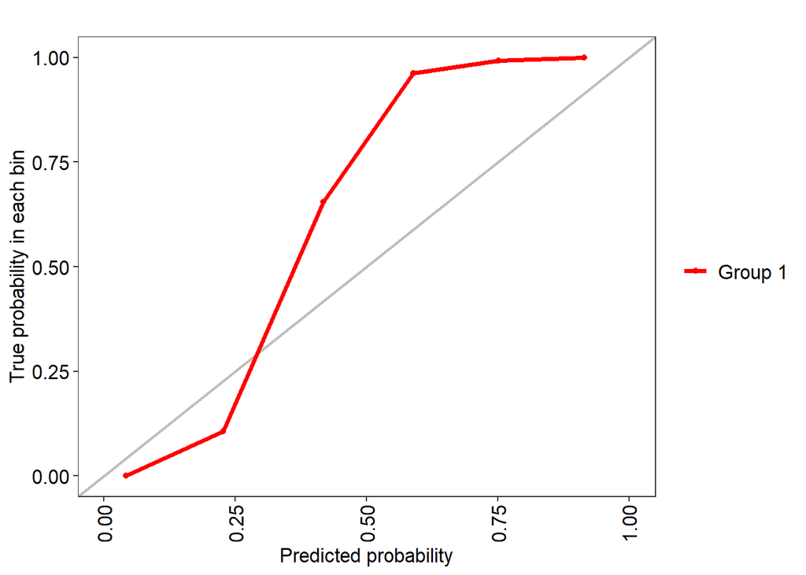

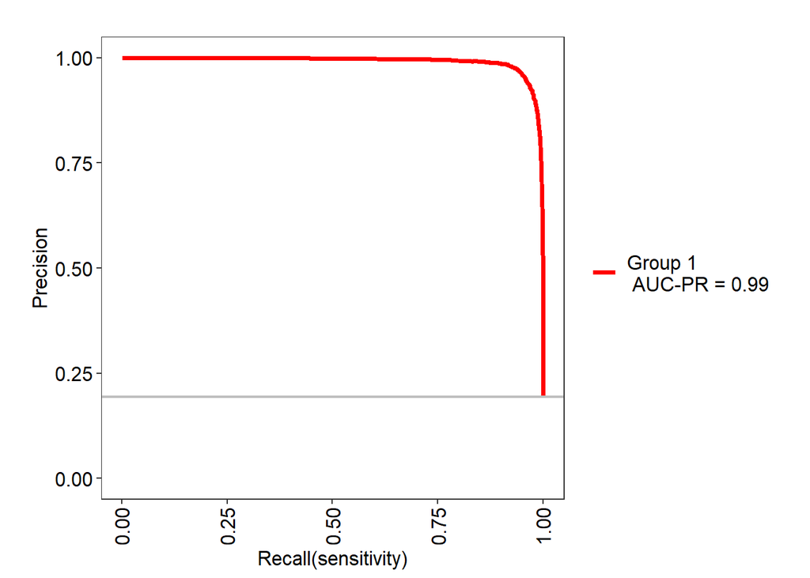

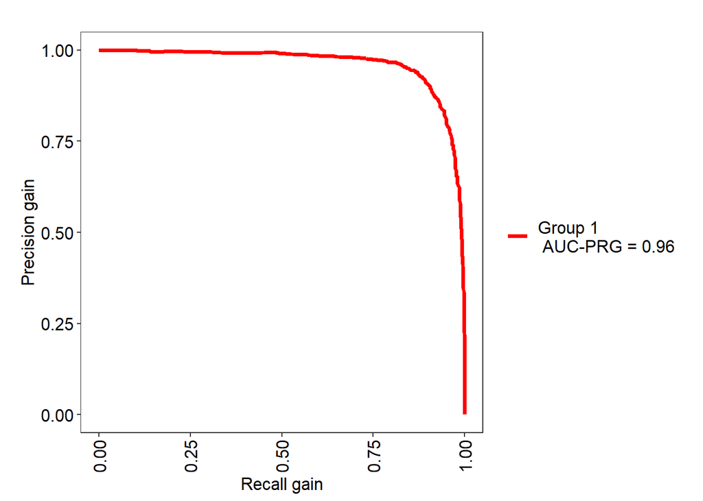

```
## Group 1 Optimal Informedness = 0.954859812777532
```

```
## Group 1 AUC-ROC = 1
```

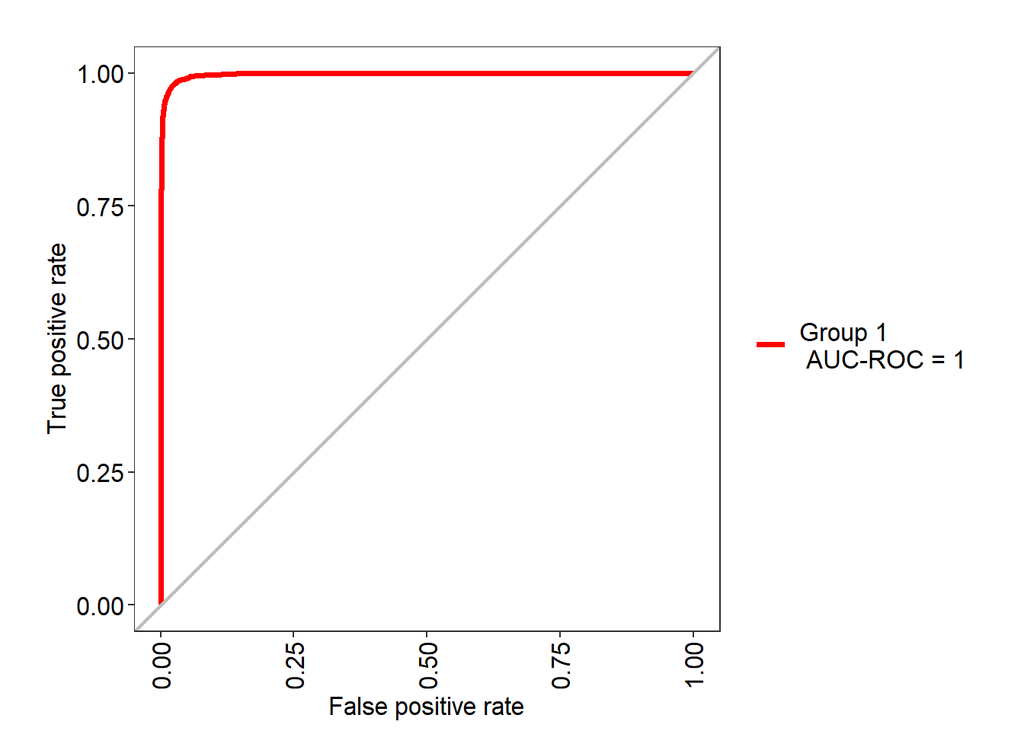

```r
# load library to make ROC plots
library(MLeval)
## run MLeval

res <- evalm(fit_rf)
```

Using our random forest model for predicting the testing data and the associated confusion matrix:

```r
# Random forest has best accuracy based on training data
# will move forward with random forest
pred <- predict(fit_rf, testing)

confusionMatrix(testing$classe, pred)
```

```
## Confusion Matrix and Statistics
##
##           Reference
## Prediction    A    B    C    D    E
##          A 2179   12   19   20    2
##          B   15 1482   15    6    0
##          C    9    9 1304   46    0
##          D    7    5   43 1229    2
##          E    5    7   11    5 1414
##
## Overall Statistics
##
##                Accuracy : 0.9697
##                  95% CI : (0.9656, 0.9733)
##     No Information Rate : 0.2823
##     P-Value [Acc > NIR] : < 2.2e-16
##
##                   Kappa : 0.9616
##
##  Mcnemar's Test P-Value : 0.0003398
##
## Statistics by Class:
##
##                      Class: A Class: B Class: C Class: D Class: E
## Sensitivity            0.9837   0.9782   0.9368   0.9410   0.9972
## Specificity            0.9906   0.9943   0.9901   0.9913   0.9956
## Pos Pred Value         0.9763   0.9763   0.9532   0.9557   0.9806
## Neg Pred Value         0.9936   0.9948   0.9864   0.9883   0.9994
## Prevalence             0.2823   0.1931   0.1774   0.1665   0.1807
## Detection Rate         0.2777   0.1889   0.1662   0.1566   0.1802
## Detection Prevalence   0.2845   0.1935   0.1744   0.1639   0.1838
## Balanced Accuracy      0.9872   0.9863   0.9634   0.9662   0.9964
```

I expect out of sample accuracy to be slightly less than 97%.